# Prosper Loan Data

Ahmed Khaled Taha

August 18, 2018

## Here We will show the dataset structure

```
## 'data.frame':    113937 obs. of  81 variables:
##  $ ListingKey                         : Factor w/ 113066 levels "00003546482094282EF90E5",..: 7180 7193 6647 6669 6686 6689 6699 6706 6687 6687 ...
##  $ ListingNumber                      : int  193129 1209647 81716 658116 909464 1074836 750899 768193 1023355 1023355 ...
##  $ ListingCreationDate                : Factor w/ 113064 levels "2005-11-09 20:44:28.847000000",..: 14184 111894 6429 64760 85967 100310 72556 74019 97834 97834 ...
##  $ CreditGrade                        : Factor w/ 9 levels "","A","AA","B",..: 5 1 8 1 1 1 1 1 1 1 ...
##  $ Term                               : int  36 36 36 36 36 60 36 36 36 36 ...
##  $ LoanStatus                         : Factor w/ 12 levels "Cancelled","Chargedoff",..: 3 4 3 4 4 4 4 4 4 4 ...
##  $ ClosedDate                         : Factor w/ 2803 levels "","2005-11-25 00:00:00",..: 1138 1 1263 1 1 1 1 1 1 1 ...
##  $ BorrowerAPR                        : num  0.165 0.12 0.283 0.125 0.246 ...
##  $ BorrowerRate                       : num  0.158 0.092 0.275 0.0974 0.2085 ...
##  $ LenderYield                        : num  0.138 0.082 0.24 0.0874 0.1985 ...
##  $ EstimatedEffectiveYield            : num  NA 0.0796 NA 0.0849 0.1832 ...
##  $ EstimatedLoss                      : num  NA 0.0249 NA 0.0249 0.0925 ...
##  $ EstimatedReturn                    : num  NA 0.0547 NA 0.06 0.0907 ...
##  $ ProsperRating..numeric.            : int  NA 6 NA 6 3 5 2 4 7 7 ...
```

[output cut: 67 more lines]

## Dataset’s Summary

```
##                    ListingKey     ListingNumber
##  17A93590655669644DB4C06:     6   Min.   :      4
##  349D3587495831350F0F648:     4   1st Qu.: 400919
##  47C1359638497431975670B:     4   Median : 600554
##  8474358854651984137201C:     4   Mean   : 627886
##  DE8535960513435199406CE:     4   3rd Qu.: 892634
##  04C13599434217079754AEE:     3   Max.   :1255725
##  (Other)                :113912
##                     ListingCreationDate  CreditGrade         Term
##  2013-10-02 17:20:16.550000000:     6          :84984   Min.   :12.00
##  2013-08-28 20:31:41.107000000:     4   C      : 5649   1st Qu.:36.00
##  2013-09-08 09:27:44.853000000:     4   D      : 5153   Median :36.00
##  2013-12-06 05:43:13.830000000:     4   B      : 4389   Mean   :40.83
##  2013-12-06 11:44:58.283000000:     4   AA     : 3509   3rd Qu.:36.00
##  2013-08-21 07:25:22.360000000:     3   HR     : 3508   Max.   :60.00
##  (Other)                      :113912   (Other): 6745
##                  LoanStatus                  ClosedDate
##  Current              :56576                      :58848
##  Completed            :38074   2014-03-04 00:00:00:  105
##  Chargedoff           :11992   2014-02-19 00:00:00:  100
##  Defaulted            : 5018   2014-02-11 00:00:00:   92
##  Past Due (1-15 days) :  806   2012-10-30 00:00:00:   81
##  Past Due (31-60 days):  363   2013-02-26 00:00:00:   78
##  (Other)              : 1108   (Other)            :54633
##   BorrowerAPR       BorrowerRate     LenderYield
##  Min.   :0.00653   Min.   :0.0000   Min.   :-0.0100
##  1st Qu.:0.15629   1st Qu.:0.1340   1st Qu.: 0.1242
##  Median :0.20976   Median :0.1840   Median : 0.1730
##  Mean   :0.21883   Mean   :0.1928   Mean   : 0.1827
##  3rd Qu.:0.28381   3rd Qu.:0.2500   3rd Qu.: 0.2400
##  Max.   :0.51229   Max.   :0.4975   Max.   : 0.4925
##  NA's   :25
##  EstimatedEffectiveYield EstimatedLoss   EstimatedReturn
##  Min.   :-0.183          Min.   :0.005   Min.   :-0.183
##  1st Qu.: 0.116          1st Qu.:0.042   1st Qu.: 0.074
##  Median : 0.162          Median :0.072   Median : 0.092
##  Mean   : 0.169          Mean   :0.080   Mean   : 0.096
##  3rd Qu.: 0.224          3rd Qu.:0.112   3rd Qu.: 0.117
##  Max.   : 0.320          Max.   :0.366   Max.   : 0.284
##  NA's   :29084           NA's   :29084   NA's   :29084
```

[output cut: 193 more lines]

```
##  Min.   :    0.00                Min.   :0.7000   Min.   : 0.00000
##  1st Qu.:    0.00                1st Qu.:1.0000   1st Qu.: 0.00000
##  Median :    0.00                Median :1.0000   Median : 0.00000
##  Mean   :   25.14                Mean   :0.9986   Mean   : 0.04803
##  3rd Qu.:    0.00                3rd Qu.:1.0000   3rd Qu.: 0.00000
##  Max.   :21117.90                Max.   :1.0125   Max.   :39.00000
##
##  InvestmentFromFriendsCount InvestmentFromFriendsAmount   Investors
##  Min.   : 0.00000           Min.   :    0.00            Min.   :   1.00
##  1st Qu.: 0.00000           1st Qu.:    0.00            1st Qu.:   2.00
##  Median : 0.00000           Median :    0.00            Median :  44.00
##  Mean   : 0.02346           Mean   :   16.55            Mean   :  80.48
##  3rd Qu.: 0.00000           3rd Qu.:    0.00            3rd Qu.: 115.00
##  Max.   :33.00000           Max.   :25000.00            Max.   :1189.00
##
```

# Univariate Plots Section

First we will clean our data, make some new variables that will be essential for exploration.

One of the most related variables to prosper rating is CreditScore, so we will form CreditScore Variable by averaging CreditScoreRangeLower and CreditScoreRangeUpper

Also, we will change all dates columns into Date format

We will change the format of LoanOriginationQuarter to begin with the year, to be suitable for our visualizations

We will form a CreditGrade general variable using both CreditGrade (Pre 2009 Loans) & ProsperRating..Alpha. (Post 2009 Loans)

At last, we will extract year, month, day variables from dates to make real time plots

**Plots**: Now, let’s do some plots after running summary of our data.

First Variable we will discuss is LoanOriginal Amount

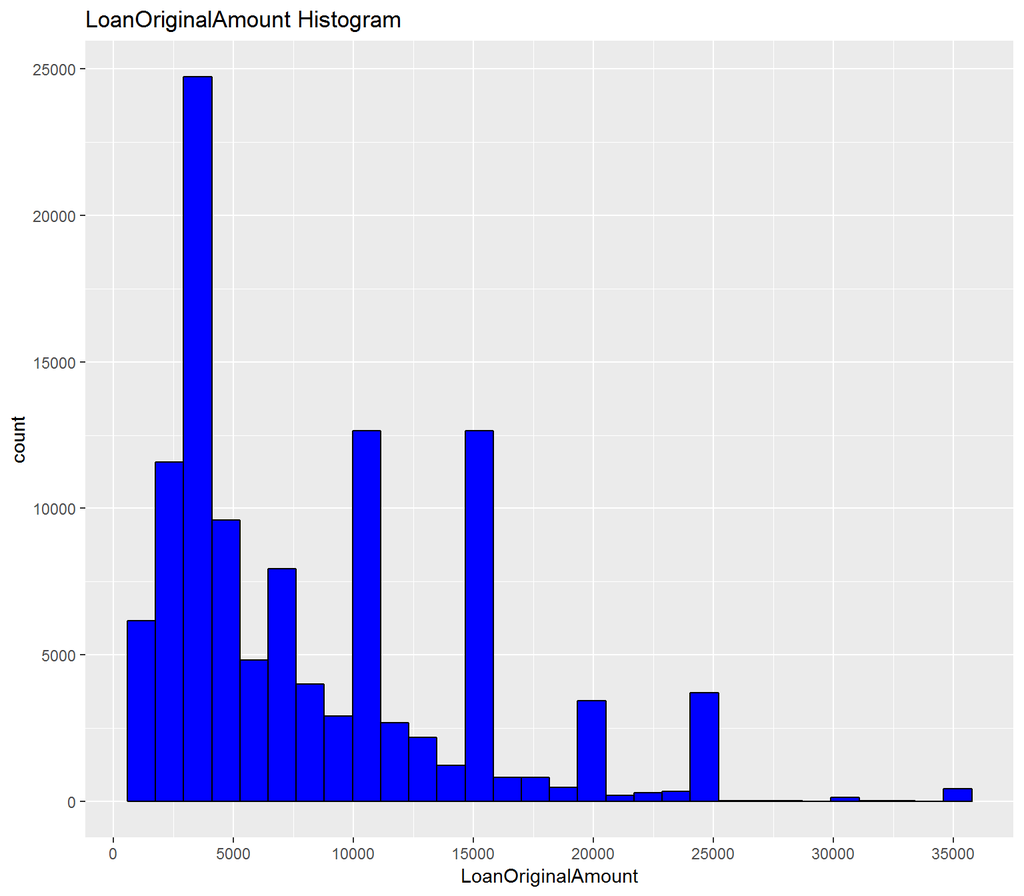

As we see here, most Loans were below 15000$, Also there is a spike at each 5000$ multiple.

Now we will study the listing Date histograms

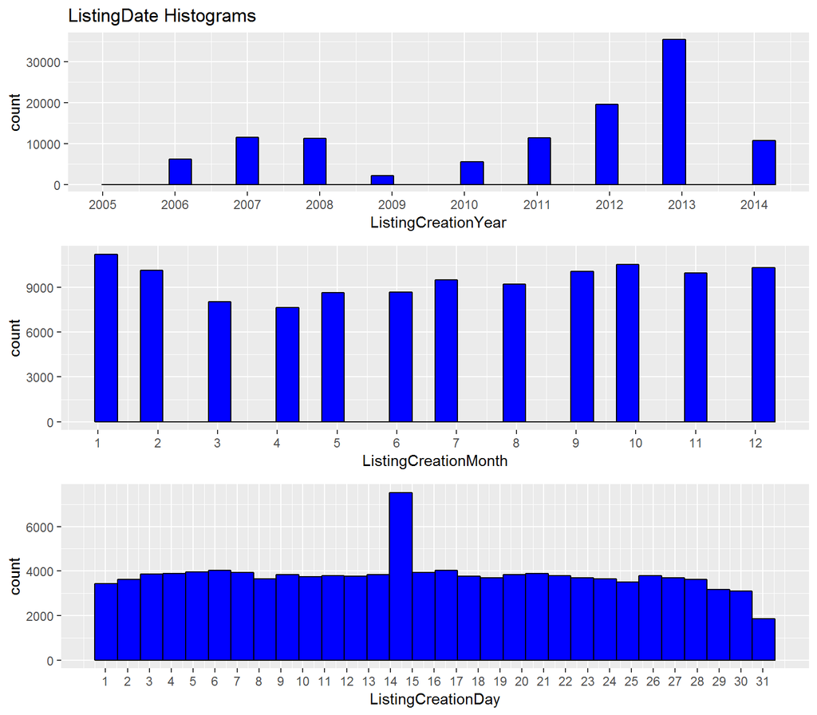

We will do the same for the Origination Date

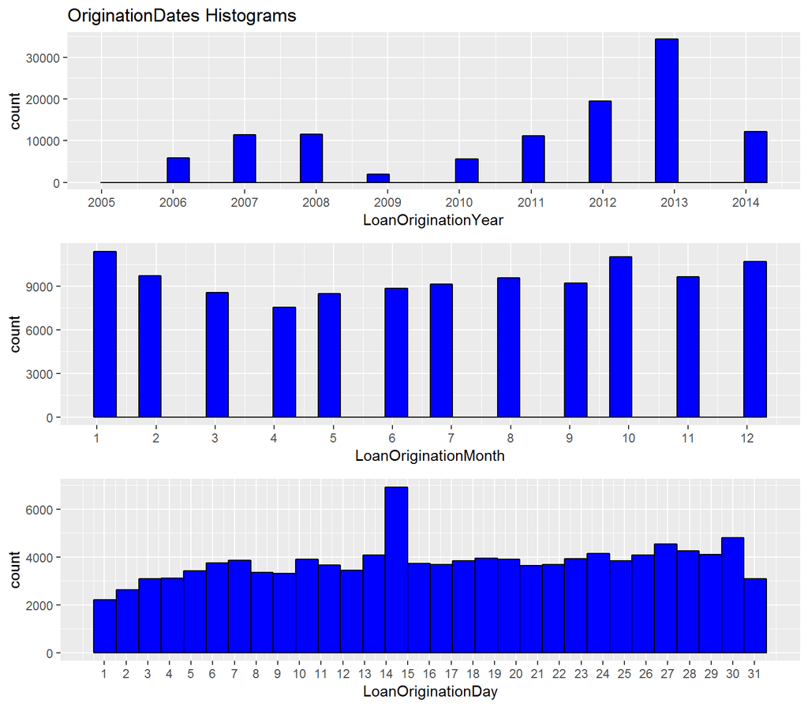

The distribution is nearly the same as listing dates, with a difference in the days distribution as the highest after the middle of the month is day number 30

Now we will do the same for ClosingDates

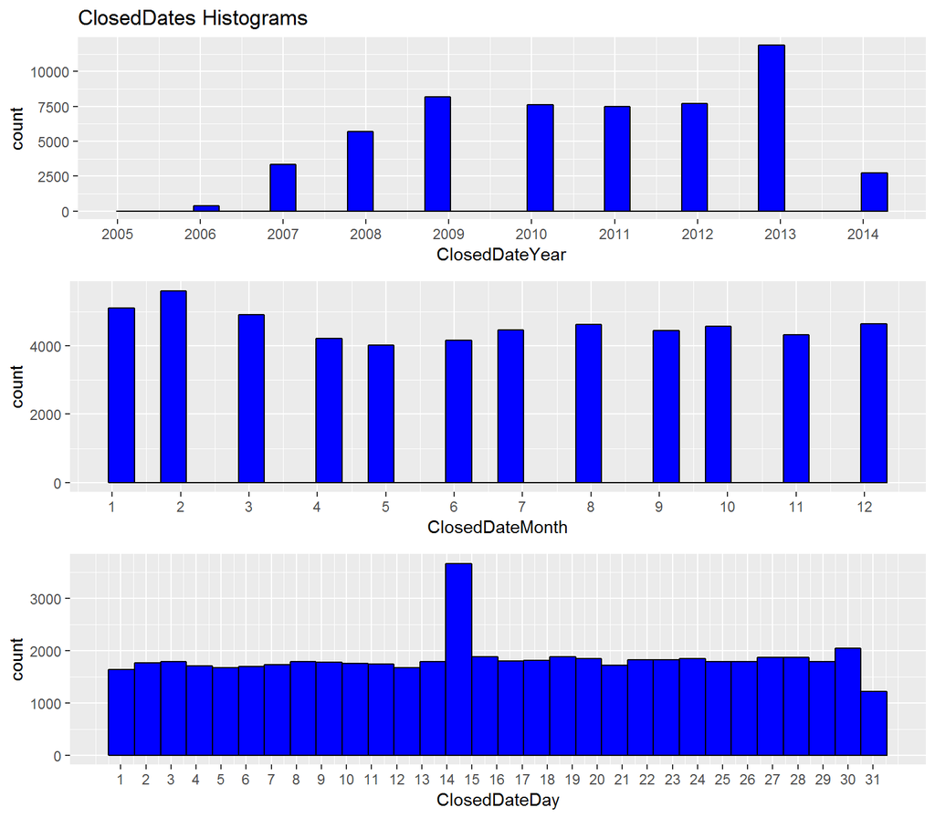

More loans are closed in 2013, Due to the fact that more loans were originated in it, also more loans are closed in the middle of the month, which makes sense because most of the loans originated on it.

Now let’s study the borrowers

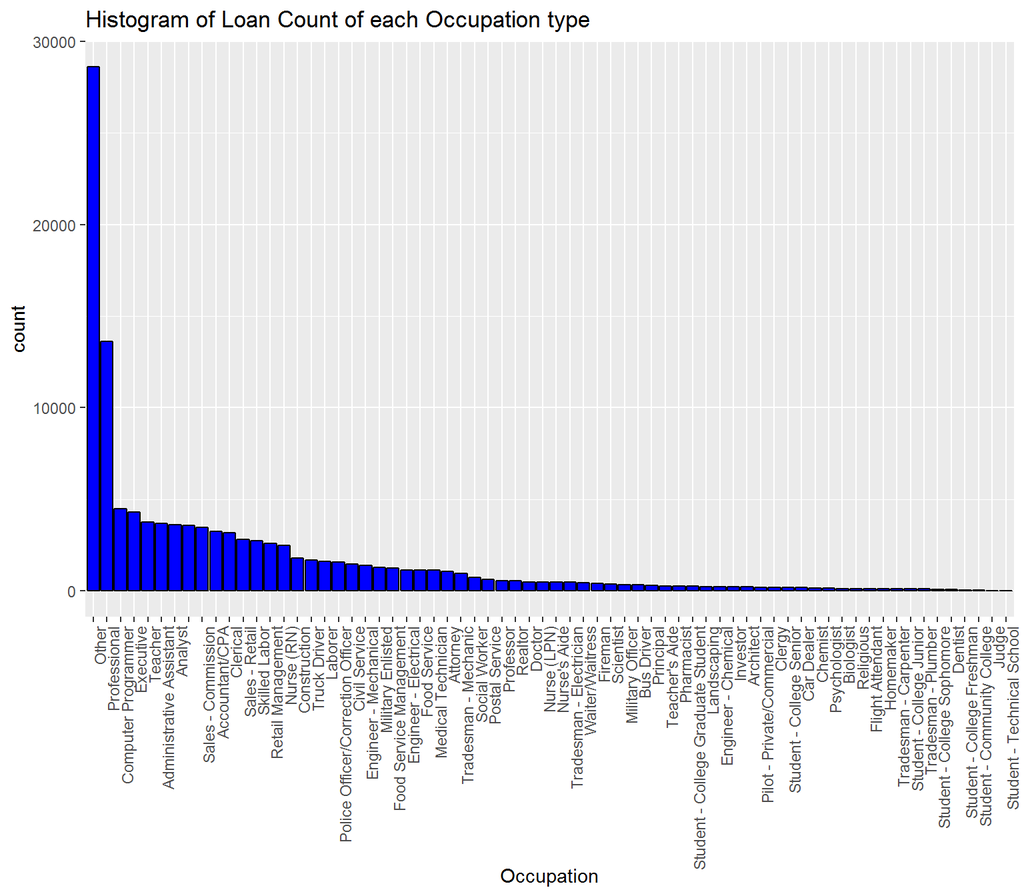

The highest loans are done by occupation type Other, followed by Professionals

Let’s study the state where the Loans are originated

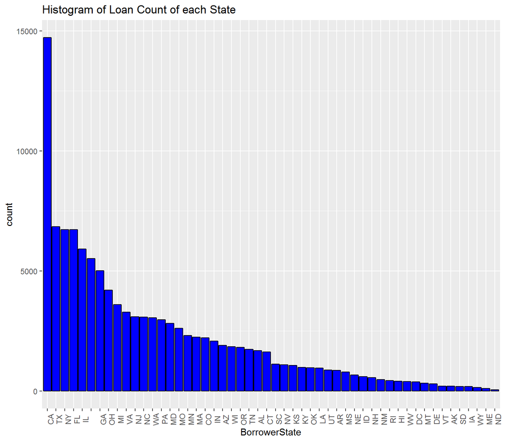

The most Borrowers are from California, followed by Texas

Now, we will study the income range

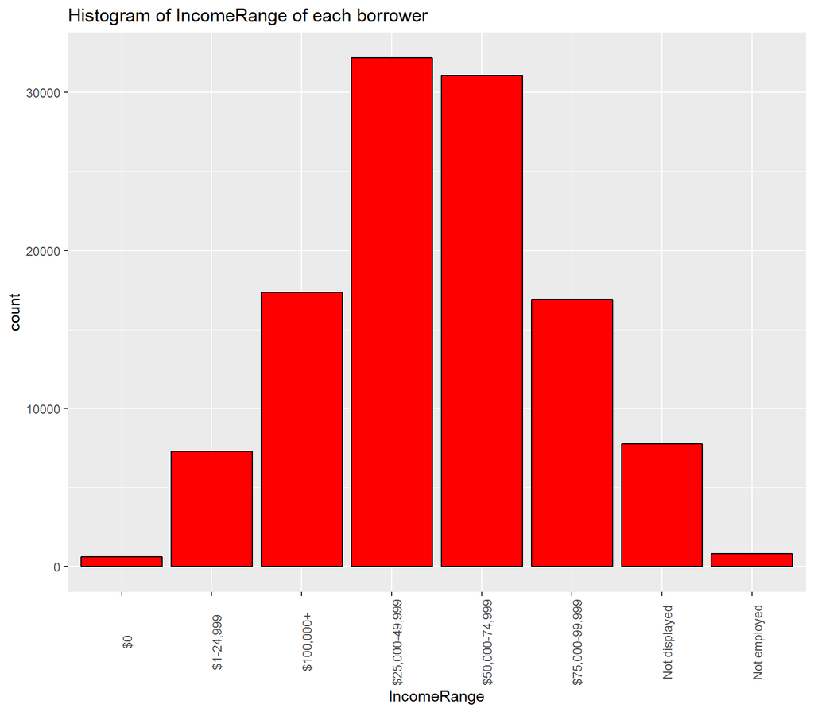

The plot is nearly normal distribution

Now, for the CreditScore

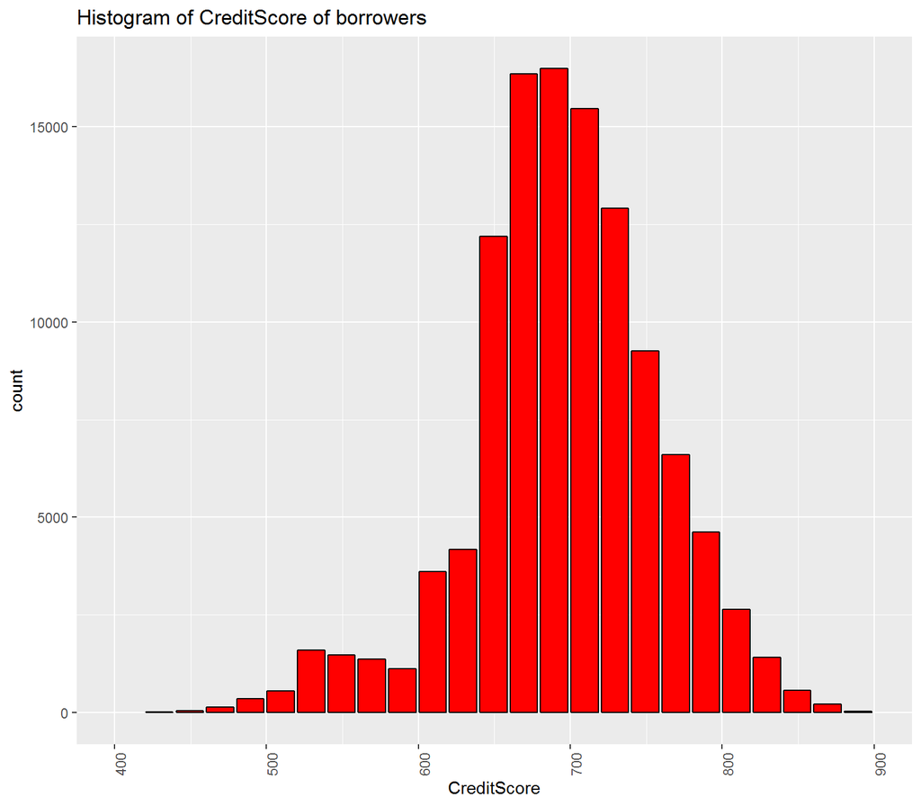

As we see, this plot is also a nearly normal distribution approximately center at CreditScore = 700

Now we will plot the Debt-To-Income Ratio

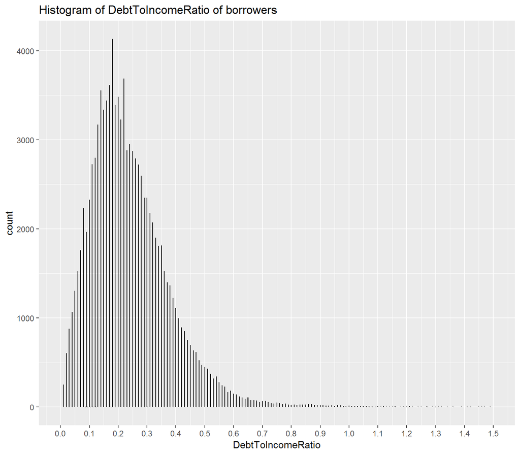

The bulk of data is below 0.7 with the median being 0.2

Let’s study the delinquencies now

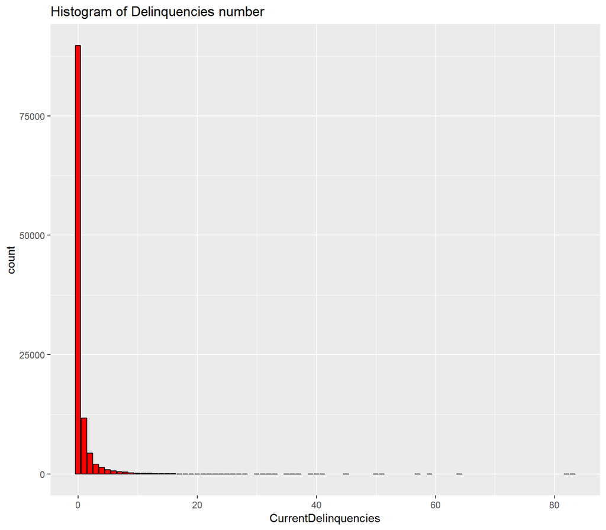

This is a very good indication, as the most of Borrowers have 0 delinquencies

Now, we will plot a time series plot describing the relation between LoanStatus and The year quarter

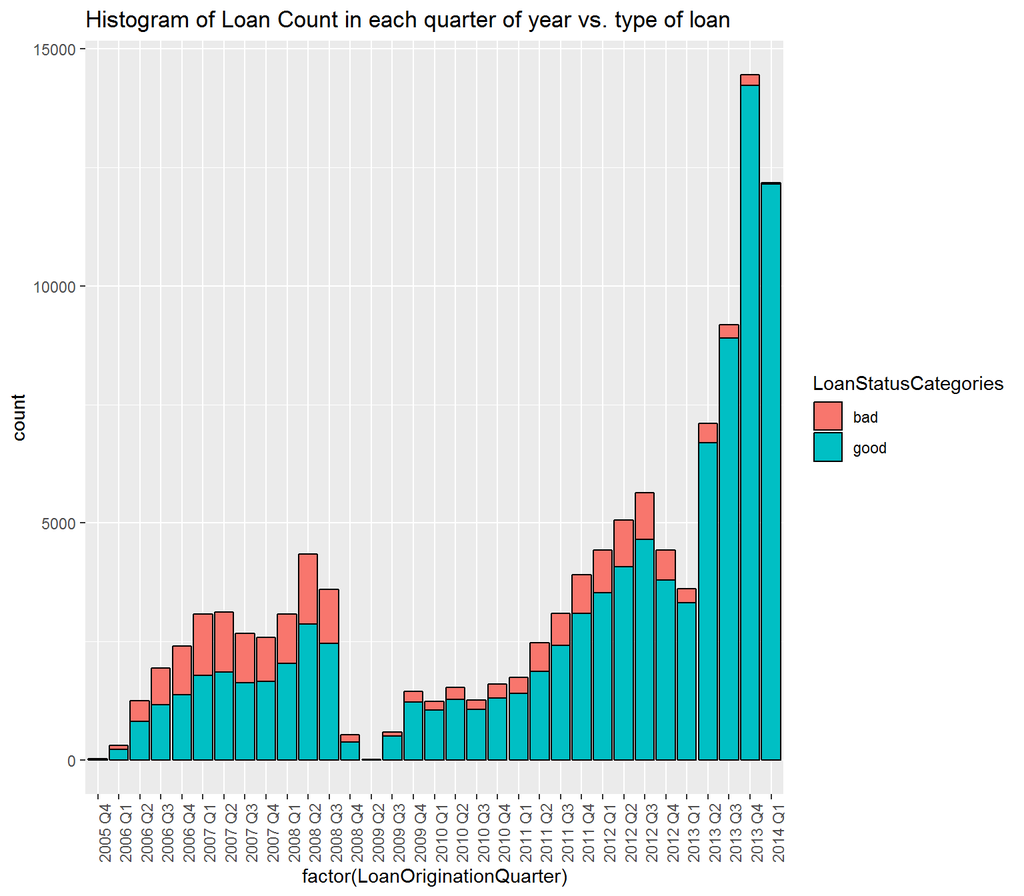

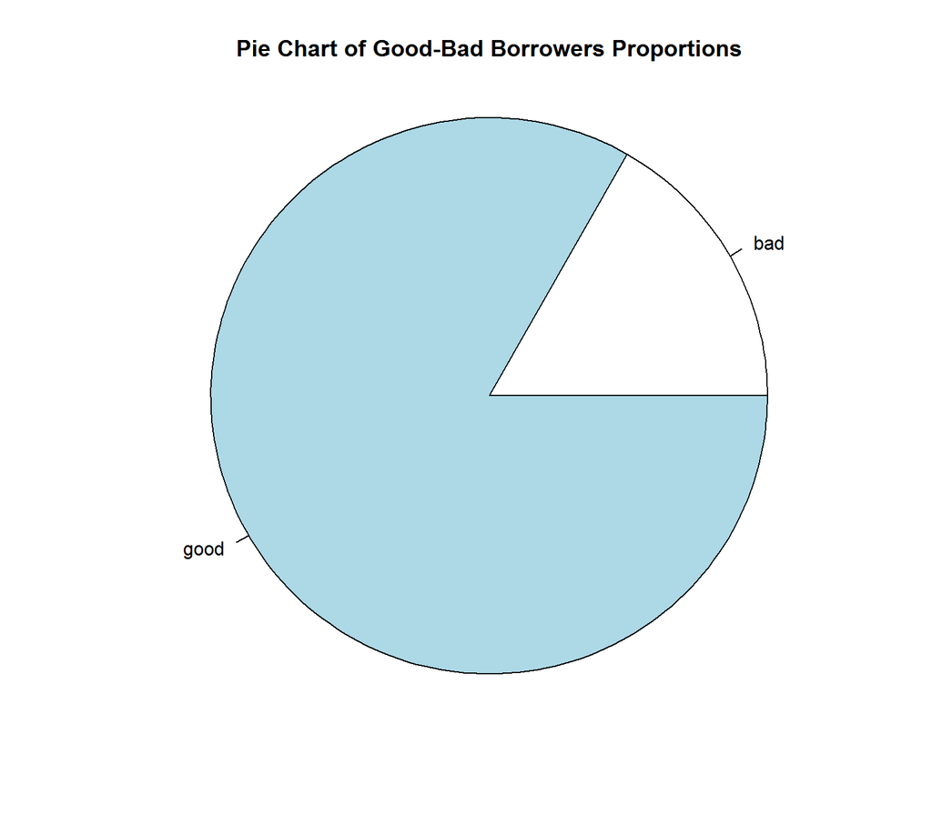

The first plot proves that the company is growing, since number of loans increasing by the time, also the second plot refers that Good Customers are far more than bad Customers

# Univariate Analysis

### What is the structure of your dataset?

113937 Observations of 81 Variables

### What is/are the main feature(s) of interest in your dataset?

ProsperRatings,ProsperScore, AmountDelinquint, Total inquiries, DebtToIncomeRatio, CreditUtilization, CurrentDelinquincies, Dates of Closing,Origination And Listing.

### What other features in the dataset do you think will help support your investigation into your feature(s) of interest?

all CreditScore, Also the Term, Employment, Occupation, EmploymentDuration, IsBorrowerHomeOwner, IsInGroup, TradesNeverDelinquent..percentage.

### Did you create any new variables from existing variables in the dataset?

Yes, i created a new Credit score variable by averaging both upper and lower range, then i created a modified LoanOriginationQuarter to convert it to a date to make it’s plot well ordered, also i split up all dates into Years,Months,Days, Also i added CreditGrade and ProsperRating..Alpha to one variable as they reflect the same thing but on two different periods

### Of the features you investigated, were there any unusual distributions? Did you perform any operations on the data to tidy, adjust, or change the form of the data? If so, why did you do this?

No, all the visualization nearly make sense, i only plotted some histograms, and for the distributions, all seems fine, even the skewed distribution make sense.

# Bivariate Plots Section

Now, we will see relations between two features, we will start with the relation between TotalCreditGrade & CreditScore, Since one of them is categorical, we will use box plots

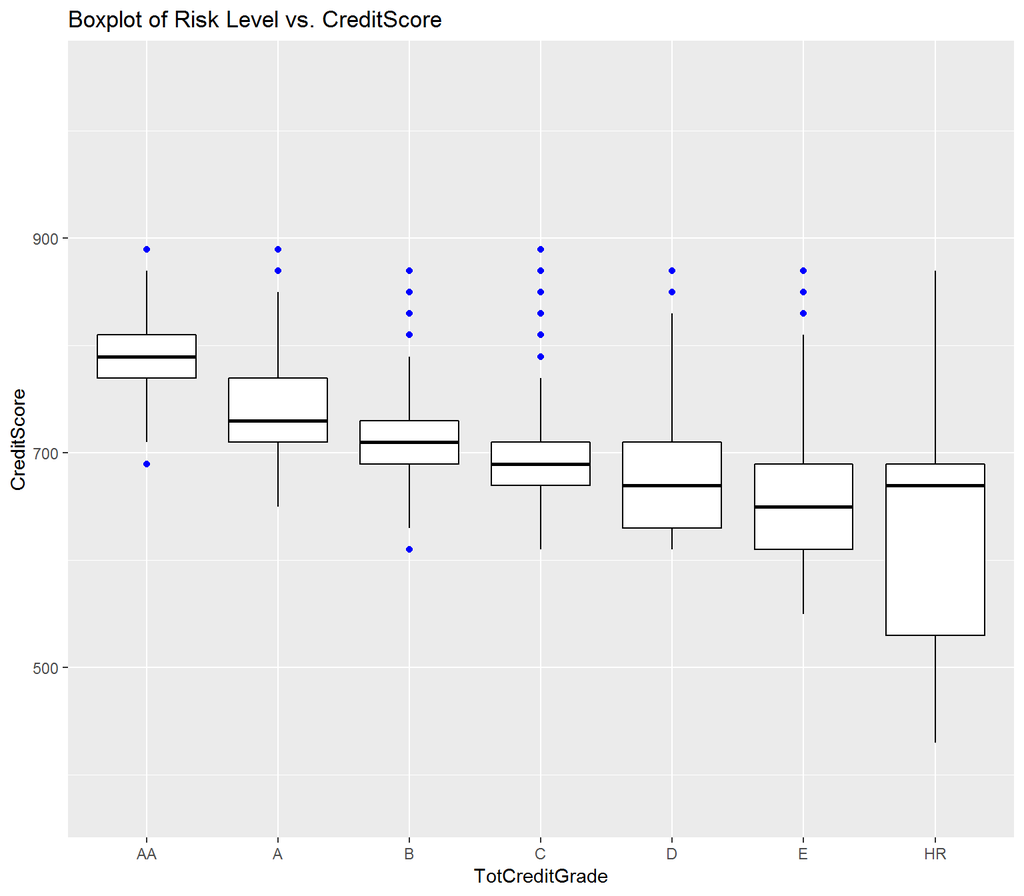

As we see, as we go higher in risk (To the right), The CreditScore is going down, and this makes sense because more CreditScore Means more propability for a borrower to complete his loan.

Now, we will do the same but for the BorrowerAPR vs TotCreditGrade

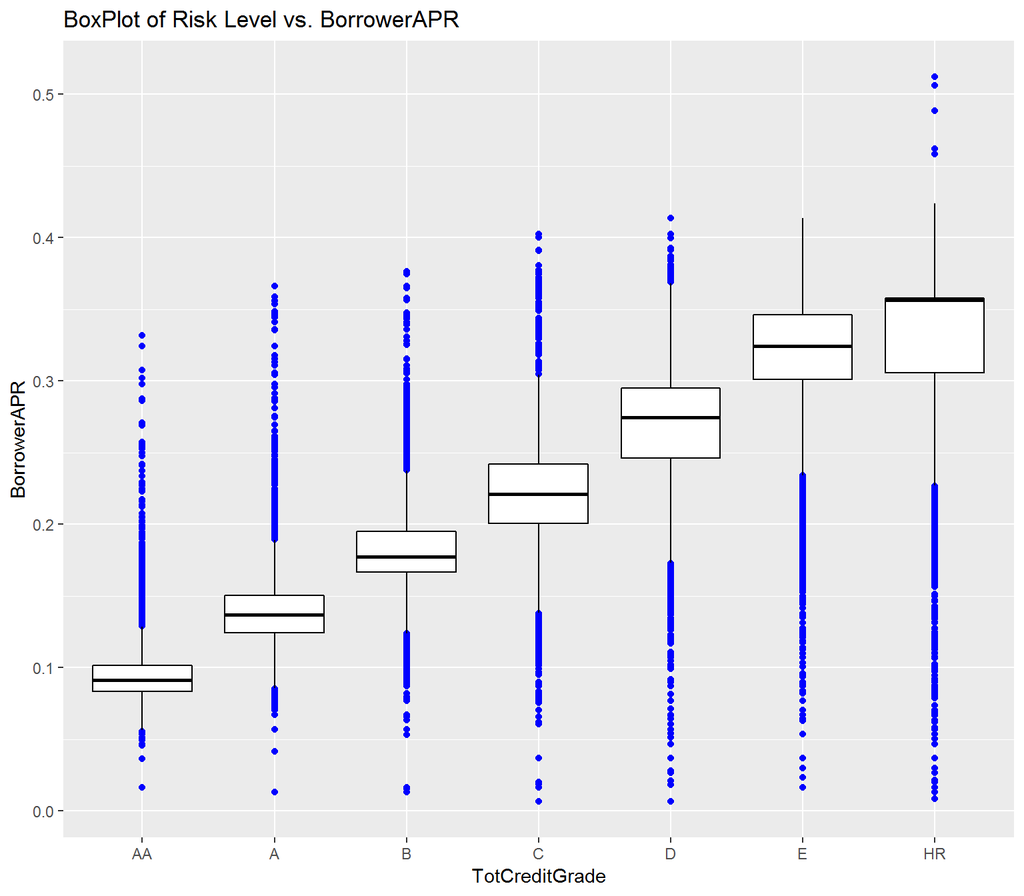

Again, the visualization is making alot of sense, as we step up in the ladder of risk, from low to high, we increase the Borrower Annual Percentage Rate

Now, we will study the Loan Categories (Bad,Good) vs quarters with line plots

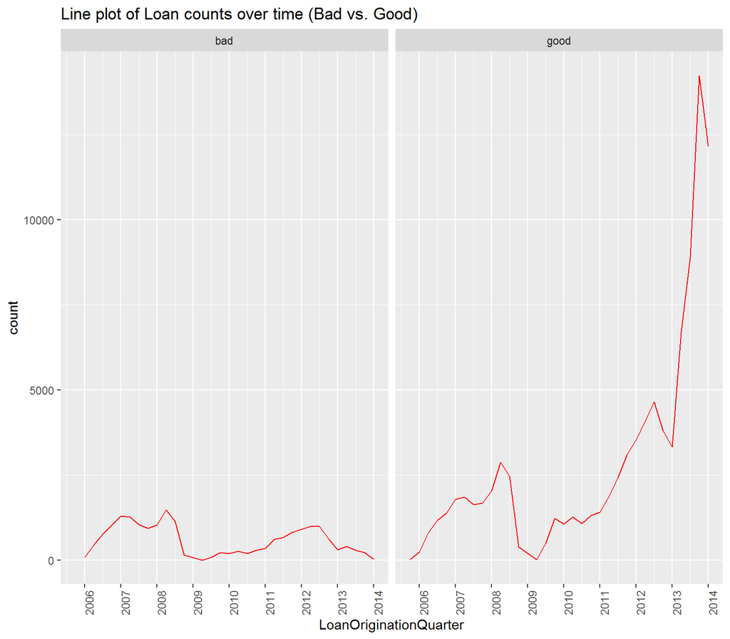

As we see, good customers increased alot from 2013 to 2014, also as we referred before, 2009 has the lowest bad and good customers rates as there wes a financial Crisis.

Now, let’s see the relation between TotCreditGrade and AmountDelinquent

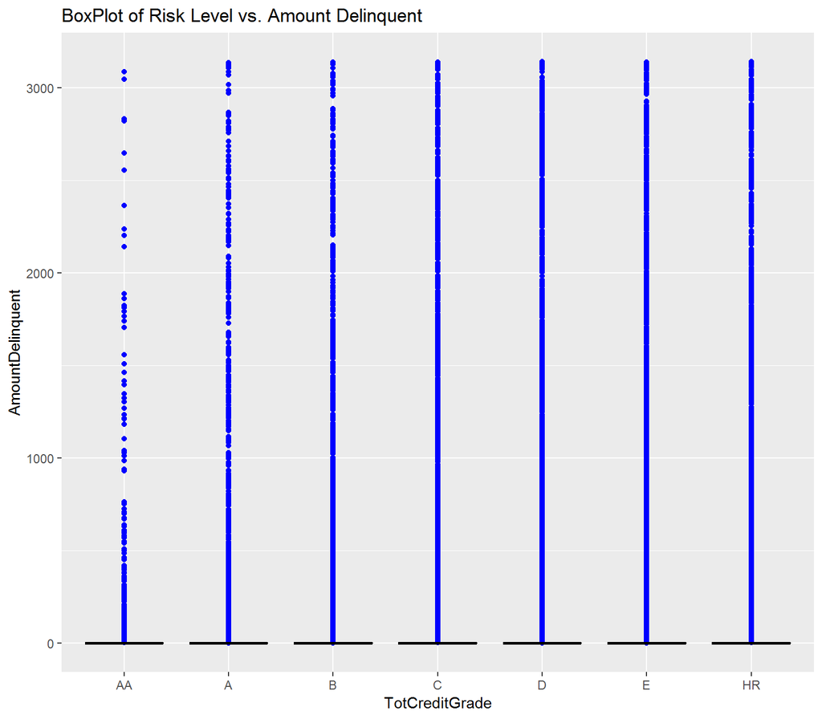

This result here seems weird as a visualization, but it clearly support our exploration above, that said most of People has no delinquencies, here, the median of Amount Delinquent is nearly = 0 for all risk levels, which means the bulk of data has no delinquencies.

Then we will study the relation between Loan Status and the Term Length, Because i have an initial thought that LoanStatus will be easier to complete if the Term is higher

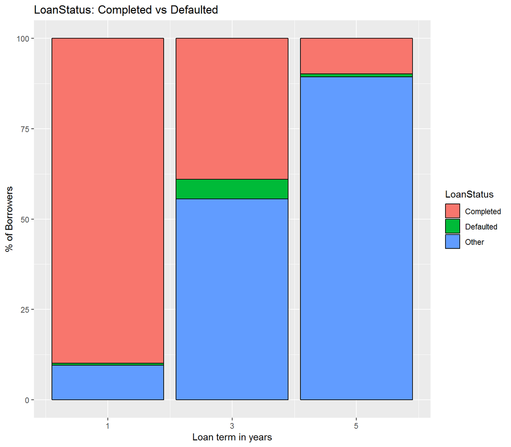

That means that according to this plot, my initial thought was wrong, as there is no trend in Defaulted LoanStatus. So decision cannot be made until we explore the dataset further

# Bivariate Analysis

So now, we know that ProsperRating is related strongly with BorrowerAPR, CreditScore

Also, we know that good customers is growing in the last year and bad customers are decreasing.

And we have another proof that Most of our customers has no delinquencies

# Multivariate Plots Section

Now, let’s see the relation between Risk levels, APR, and Debt-To-Income all together

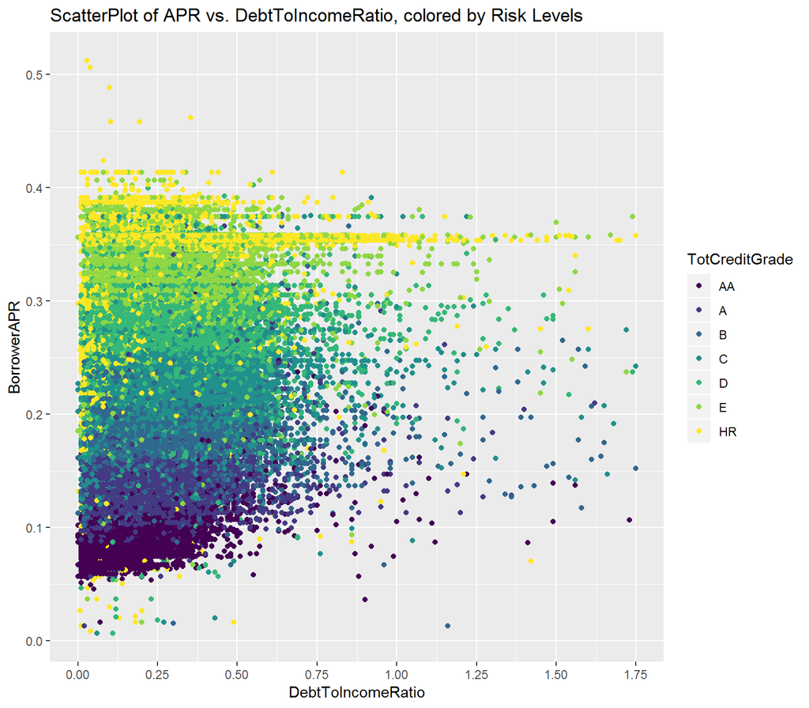

Now, we will do the same but with the lender yield vs Loan Original ammount, for each customer category (bad,good), and color it with the Risk level

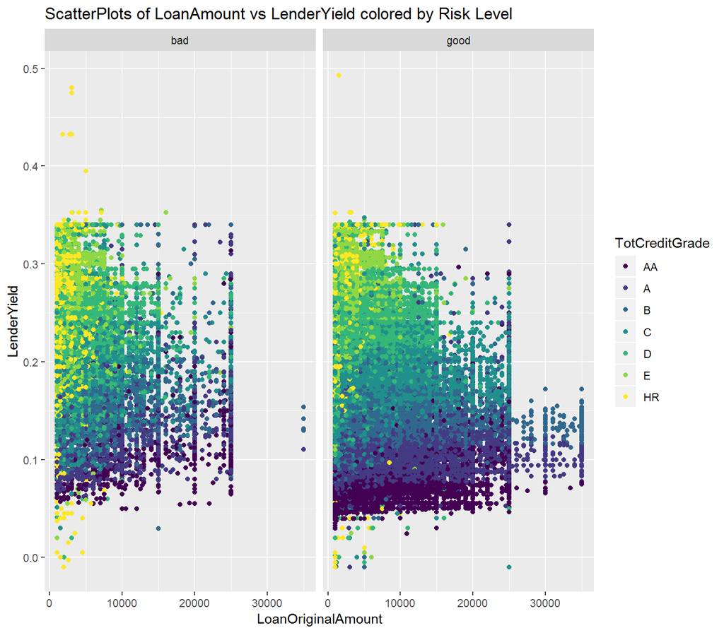

In this plot we see that for good loans, LoanOriginalAmount has bigger range eventually, also as we increase the lender yield, The risk increases, Also we can observe vertical strict lines at each multiple of 5000$, and this make sense as most loans are given in those multiples.

# Multivariate Analysis

Also we explored the LoanAmount, LenderYield & Risk Level, we found the same correlation between the 3 features, and the effect of them on RiskLevels.

# Final Plots and Summary

### Plot One

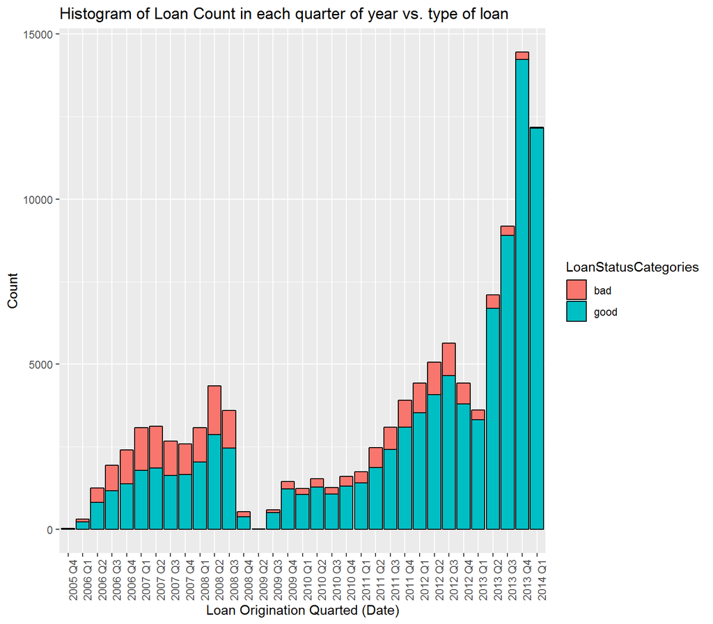

### Description One

This is nearly the most informative plot of all the plots i made, it tells us alot about the company evolution, the efficiency of Loans, and the difference between before the Crisis and after the Crisis,

First, in the period before 2009, we have The loans nearly split to 40% bad, 60% good, which is not very good, this is a high rate of failure in the loan system, which can make it so hard for lenders to invest in big loans

Second, in the period after 2009, we have this changed, the majority of the loans are of a good status, also the number of loans are much higher, which refers to a Company Evolution, and Performance efficiency increasing.

### Plot Two

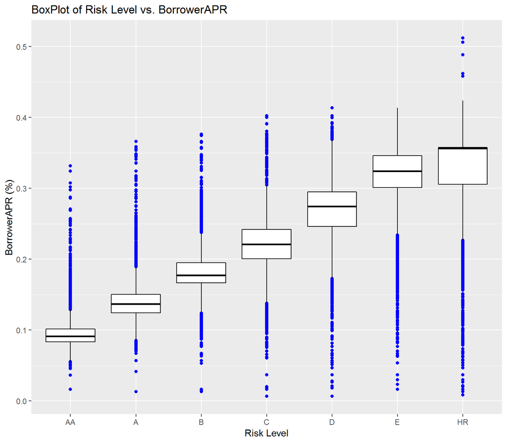

### Description Two

This is an easy to intrepret plot, yet it shows a clear relation between Risk levels and borrowers APR, in which , in some cases can be used to build a predictive model to predict the TotCreditGrade, Along with some other features like (DebtToIncomeRatio, AmountDelinquent, TotalInquiries, CreditLines, etc…)

This predictive model is not the regular linear regression, it should be a multilevel classifier, as we are prediciting a multi-level categorical variable. (Needs a machine learning base)

### Plot Three

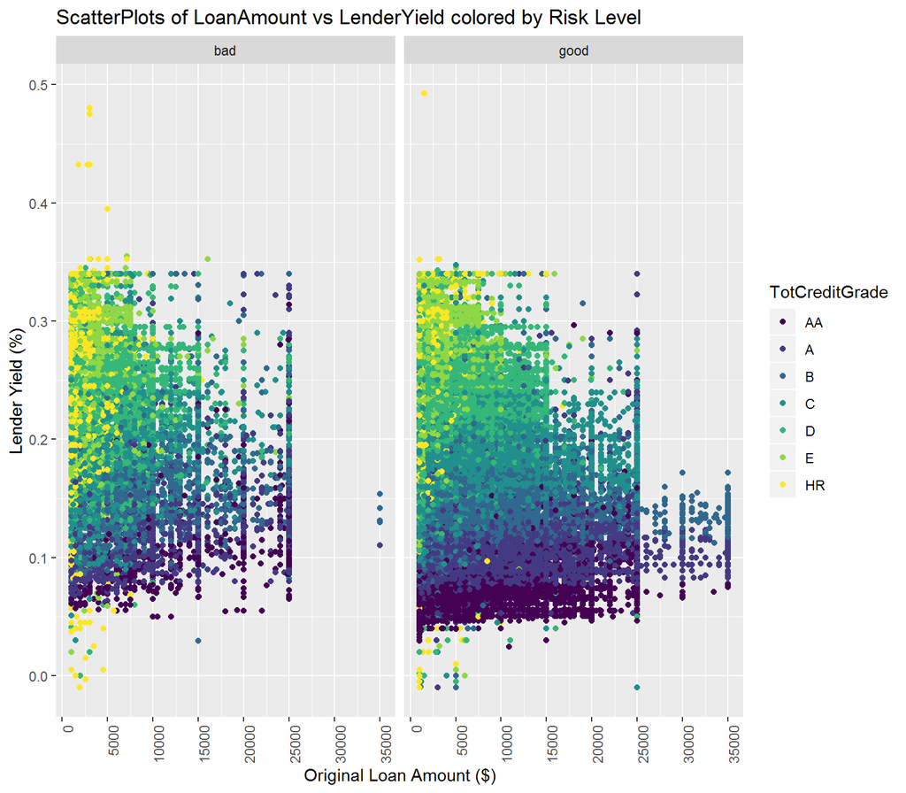

### Description Three

And here, the final plot i will put in this section, that has many information inside it, the relation between LoanAmount and Lenderyield Studied with RiskLevel.

First, we observe that for the bad customers, a realy realy few number of loans gone higher than 25000$, so the bulk of the high loans (>25000$) are good loans.

Second, we observe that as the LenderYield increases, the risk level increases, which makes alot of sense.

# Reflection

This dataset was very challenging for me, the hardest among the choices, i didn’t know what is prosper loan is, i studied it, studied nearly all the 81 variables well, i searched for Some explorations on some datasets regarding the prosper category, it was so hard to study relations between this number of variables, but at last it was kind of rewarding.

I learnt too much, Some R functions, also i practiced Plyr and Dplyr packages, I studied the dataset alot to produce a firm Understanding to it, to begin analyzing its features.

Future work on this dataset would be a multi level classifier to predict the Risk level based on some features like (APR, Amount Delinquent, CreditScore, etc..), Also to study the LP Features.

## Resources used:

1. https://www.prosper.com/plp/about/
2. EDA Course on UDACITY
3. https://github.com/MayukhSobo/Loan_EDA
4. https://www.r-bloggers.com/